## Loading and preprocessing the data

- **1. Load the data (i.e. read.csv())**

```
library(lubridate)
library(timeDate)
activity = read.csv("activity.csv", header = T, sep = ",")
```

- **2. Process/transform the data (if necessary) into a format suitable for your analysis**

```
Sys.setlocale(category = "LC_ALL", locale = "C") # Put in English

## [1] "C"

activity$days = as.POSIXlt(activity$date,"%Y-%m-%d %H:%M:%S")
```

## What is mean total number of steps taken per day?

- **1. Calculate the total number of steps taken per day**

```
nsteps = aggregate(steps ~ date, activity, sum)
```

- **2. If you do not understand the difference between a histogram and a barplot, research the difference between them. Make a histogram of the total number of steps taken each day**

```
hist(nsteps$steps, col = "grey", xlab = "Total steps per day", ylab = "Frequency", main = "Distribution of the number of steps per day")
```

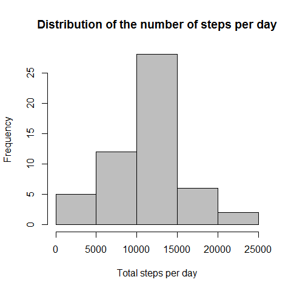

- **3. Calculate and report the mean and median of the total number of steps taken per day**

```
meanstepsperday = mean(nsteps$steps); meanstepsperday

## [1] 10766.19

medianstepsperday = median(nsteps$steps); medianstepsperday

## [1] 10765
```

The mean of the total number of steps taken per day is 10766 and the median of the total number of steps taken per day is 10765.

## What is the average daily activity pattern?

- **1. Make a time series plot (i.e. type = “l”) of the 5-minute interval (x-axis) and the average number of steps taken, averaged across all days (y-axis).**

```
avar_pattern_day = aggregate(steps ~ interval, activity, mean)
plot(avar_pattern_day$interval, avar_pattern_day$steps , type = "l", col = "blue", xlab = "5-minute interval", ylab = "average number of steps taken",
     main = "Time series of the 5-minute interval per
     average number of steps taken")
```

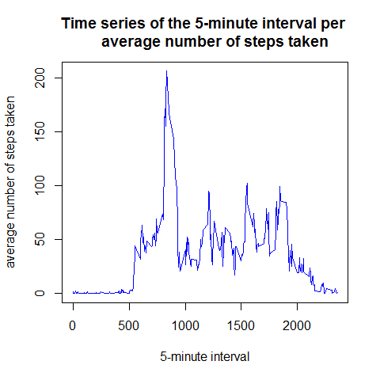

- **2. Which 5-minute interval, on average across all the days in the dataset, contains the maximum number of steps?**

```
maxsteps =  avar_pattern_day[which.max(avar_pattern_day$steps), ]
maxsteps

##     interval    steps
## 104      835 206.1698
```

The maximum steps 206.17 is on 835 interval.

## Imputing missing values

Note that there are a number of days/intervals where there are missing values (coded as NA). The presence of missing days may introduce bias into some calculations or summaries of the data.

- **1. Calculate and report the total number of missing values in the dataset (i.e. the total number of rows with NAs)**

```
anyNA(activity$steps)

## [1] TRUE

anyNA(activity$date)

## [1] FALSE

anyNA(activity$interval)

## [1] FALSE

table(is.na(activity$steps)) # because steps is only with missing values

##
## FALSE  TRUE
## 15264  2304
```

There are 2304 rows with missings values.

- **2. Devise a strategy for filling in all of the missing values in the dataset. The strategy does not need to be sophisticated. For example, you could use the mean/median for that day, or the mean for that 5-minute interval, etc.**

IÂ´ll use the mean of steps.

- **3. Create a new dataset that is equal to the original dataset but with the missing data filled in.**

```
library(Hmisc)
newData = activity
newData$steps = impute(activity$steps, fun = mean)
```

- **4. Make a histogram of the total number of steps taken each day and Calculate and report the mean and median total number of steps taken per day. Do these values differ from the estimates from the first part of the assignment? What is the impact of imputing missing data on the estimates of the total daily number of steps?**

```
newnsteps = aggregate(steps ~ date, newData, sum)
hist(newnsteps$steps, col = "grey", xlab = "Total steps per day", ylab = "Frequency", main = "Distribution of the number of steps per day
     (no missing values)")
```

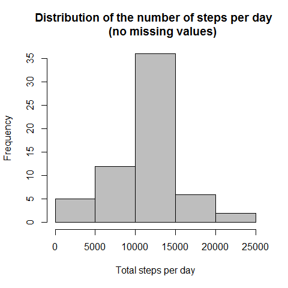

Below, after imputation we’ve the same mean for the total steps taken per day. The new median of total steps taken per day is greater than that of old median.

```
meannewstepsperday = mean(newnsteps$steps); meannewstepsperday

## [1] 10766.19

mediannewstepsperday = median(newnsteps$steps); mediannewstepsperday

## [1] 10766.19
```

## Are there differences in activity patterns between weekdays and weekends?

- **1. Create a new factor variable in the dataset with two levels - “weekday” and “weekend” indicating whether a given date is a weekday or weekend day.**

```
newData$week_days = weekdays.POSIXt(newData$days)
newData$weekdays = as.factor(ifelse(newData$week_days %in% c("Saturday","Sunday"), 'weekend', 'weekday'))
```

- **2. Make a panel plot containing a time series plot (i.e. type = “l”) of the 5-minute interval (x-axis) and the average number of steps taken, averaged across all weekday days or weekend days (y-axis). See the README file in the GitHub repository to see an example of what this plot should look like using simulated data.**

```
avgbydays = aggregate(steps ~ interval + weekdays, data = newData, mean)
library(lattice)
xyplot(avgbydays$steps ~ avgbydays$interval | avgbydays$weekdays, type = "l", xlab = "5-minute interval", ylab = "avarage number of steps", layout = c(2, 1), main = "Time series of the 5-minute interval per
       average number of steps taken and weekdays")
```

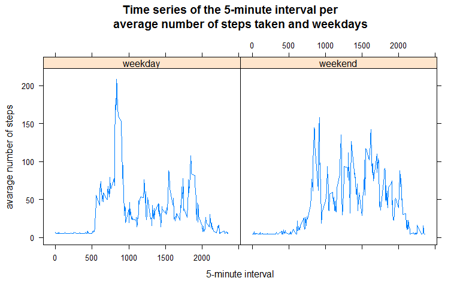

We can see some differences in activity patterns between weekdays and weekends.